# Tema 7: Variables Binarias

Jorge Sosa-García

Primavera 2023

## 7.1. Variables Cualitativas

Ahora discutiremos cómo incorporar **información cualitativa** en los modelos de regresión.

La forma más común que toma la información cualitativa es en **variables binarias** (también llamadas **variables dummy**). En estas variables se usa el número uno como registro de las las observaciones que tienen las característica (o que pertenecen al grupo) de interés y el número cero para registrar todas las demás observaciones. Al hacer esta asignación, de manera implícita se está definiendo cuál será el **grupo de referencia**.

¿Por qué se usan ceros y unos en las variables dummies?

- Siendo estrictos, no hay nada de particular en usar esa codificación ya que cualesquiera otros valores servirían.
- La ventaja de usar ceros y unos en las variables dummies está en la interpretación que se le puede dar a los coeficientes asociadas a estas variables.

## 7.2. Variables Dummy

Consideremos el caso más simple, donde se tiene una variable explicativa (numérica) y una variable dummy.

Este modeo se escribiría como:
$$y =
\beta_0 + \beta_1 x_1 + \delta_0 x_2 + u$$
En este modelo poblacional se ha usado la notación $\delta_0$ simplemente para resaltar que $x_2$ es una variable dummy ($x_2$ puede servir para identificar a dos grupos distintos: hombres y mujeres, participantes de un programa y quienes no participan, etc.), no hay ninguna otra característica especial de $x_2$ o del modelo propuesto.

De esta manera $\delta_0$ representa la diferencia en $y$ entre quienes forman parte del grupo y quienes no forman parte del grupo.

Esto es más fácil de ver de la siguiente manera:

- Cuando $x_2 = 0$ el modelo es:
  $$y = \beta_0 + \beta_1 x_1+
  u$$
- Cuando $x_2 = 1$ el modelo es
  $$y = (\beta_0 + \delta_0) + \beta_1 x_1 +
  u$$

Formalmente, esto se escribe como:
$$\delta_0 = \mathrm{E}[y | x_1, x_2 = 1] -
\mathrm{E}[y | x_1, x_2 = 0]$$
Esto es, para los mismos niveles de $x_1$, la diferencia en el valor esperado de $y$ se debe, únicamente, a $x_2$ (pertenecer o no a un grupo).

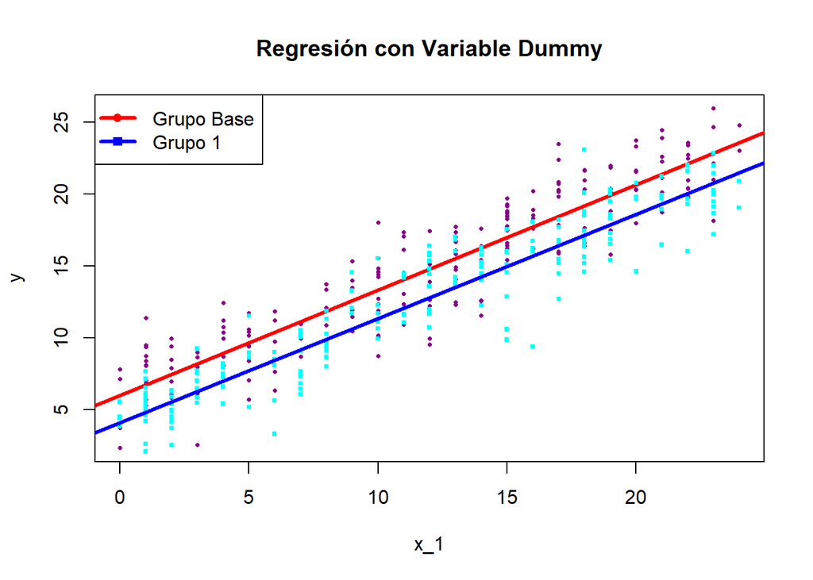

```r
# Replicabilidad
set.seed(700)

# Definicion de parametros poblacionales
b0_h <- 6
b0_l <- 4
b1 <- 0.75

# Extraccion de muestra (fuera del grupo)
x_h <- round(runif(200, 0, 24))
u_h <- rnorm(200, 0, 2)
y_h <- b0_h + b1 * x_h + u_h
s_h <- rep(0, 200)

# Extraccion de muestra (en el grupo)
x_l <- round(runif(200, 0,24))
u_l <- rnorm(200, 0, 2)
y_l <- b0_l + b1 * x_l + u_l
s_l <- rep(1, 200)

# Creacion de base de datos
base <- tibble(y = c(y_h, y_l),
               x = c(x_h, x_l),
               s = c(s_h, s_l))

# Estimacion de modelos
mod_h <- lm(y ~ x, data = base, subset = (s == 0))
mod_l <- lm(y ~ x , data = base, subset = (s == 1))
mod <- lm(y ~ x + s , data = base)

# Bases para grafica
base_h <- filter(base, s == 0)
base_l <- filter(base, s == 1)

# Grafica (fuera del grupo)
with(base_h,
     plot(x, y, col = "darkmagenta",
          pch = 16, cex = 0.50,
          main = "Regresión con Variable Dummy",
          xlab = "x_1",
          ylab = "y"))
abline(mod_h, col = "red", lwd = 3)

# Grafica (en el grupo)
with(base_l,
     points(x, y, col = "cyan",
            pch = 15, cex = 0.50, add = TRUE))
abline(mod_l, col = "blue", lwd = 3)

# Legend
legend("topleft",
       col = c("red", "blue"),
       pch = c(16, 15),
       lwd = c(3, 3),
       legend  = c("Grupo Base", "Grupo 1"))
```

Al definir la variable dummy se eligió un grupo de referencia (donde $x_2 = 0$). Esta definición es la que hace que el intercepto de la regresión del grupo de referencia sea $\beta_0$ y que $\delta_0$ sea la diferencia entre el grupo de referencia y el grupo de interés, de forma que el intercepto de la regresión del grupo de interés es $\beta_0 + \delta_0$.

Nada más que esta interpretación cambia cuando se incorporan variables dummy en las regresiones.

## 7.3. Variables Dummy para Varias Categorías

También es posible usar múltiples variables dummies en una misma ecuación de regresión. En este caso el principio general es sencillo: **si se tienen** $g$ **grupos diferentes que se quieren incorporar, entonces se deberán usar** $g-1$ **variables dummies y un intercepto**.

Suponga que se tiene una variable categórica $w$ que ordena en $g$ grupos diferentes la información de una variable (esta variable puede contener un orden o no, lo importante es que define grupos dentro de la muestra aleatoria). ¿Cómo se incorporaría esta variable en un modelo de regresión?

Una primera idea sería incorporar la variable $w$ como un regresor adicional en el modelo:
$$y = \beta_0 + \beta_1 w +
otros\:factores$$

Esta idea podría ser buena siempre y cuando $\beta_1$ proporcione una interpretación coherente del efecto de $w$ sobre $y$. En este caso, por ejemplo, $\beta_1$ indicaría la magnitud del efecto que se tiene cuando $w$ incrementa en una unidad ($w$ pasa de una categoría a otra). Esto podría ser adecuado para algunos casos, pero para la gran mayoría de las casos prácticos esta interpretación no tiene sentido.

Un mejor enfoque sería definir una variable dummy para cada nivel/grupo definido por $w$ de la siguiente manera: para cada $j \in \{1, 2, ..., g-1\}$, sea $w_j = 1$ si $w = j$ y $w_j = 0$ en otro caso. De esta manera el modelo se escribe como:
$$y = \beta_0 +
\delta_1 w_1 + \delta_2 w_2 + ... + \delta_{g-1} w_{g-1} +
otros\:factores$$
Notemos que, aunque la variable $w$ define $g$ grupos, el modelo sólo considera $g-1$ coeficientes. En este caso, el grupo $w = g$ queda excluido de la regresión y se convierte en el grupo de referencia. De esta manera, los coeficientes $\delta_j$ representa la diferencia observadas en $y$ de *cada grupo comparado con el grupo de referencia*, de modo que las ecuaciones estimadas se podría escribir como:

- Para el grupo de referencia:
  $$y =
  \beta_0 + otros\:factores$$
- Para el grupo donde $w = 1$:
  $$y = (\beta_0 + \delta_1) +
  otros\:factores$$
- Para el grupo donde $w = 2$:
  $$y = (\beta_0 + \delta_2) +
  otros\:factores$$
- Para el grupo donde $w = j$:
  $$y = (\beta_0 + \delta_j) +
  otros\:factores$$

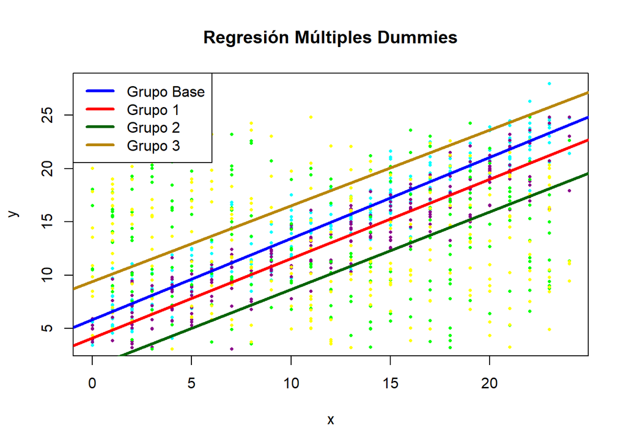

```r
# Replicabilidad
set.seed(700)

# Definicion de parametros poblacionales
b0 <- 6
b1 <- 0.75
d1 <- -2
d2 <- -5
d3 <- 3

# Extraccion de muestra (fuera del grupo)
x <- round(runif(1000, 0, 24))
u <- rnorm(1000, 0, 2)
y_0 <- b0 + b1 * x[1:250] + u[1:250]
y_1 <- (b0 + d1) + b1 * x[251:500] + u[251:500]
y_2 <- (b0 + d2) + b1 * x[501:750] + u[501:750]
y_3 <- (b0 + d3) + b1 * x[751:1000] + u[751:1000]

# Estimacion de modelos
mod_0 <- lm(y_0 ~ x[1:250])
mod_1 <- lm(y_1 ~ x[251:500])
mod_2 <- lm(y_2 ~ x[501:750])
mod_3 <- lm(y_3 ~ x[751:1000])

# Graficas
plot(x[1:250], y_0,
     col = "cyan",
     pch = 16, cex = 0.50,
     main = "Regresión Múltiples Dummies",
     xlab = "x",
     ylab = "y")
points(x[251:500], y_1,
     col = "darkmagenta",
     pch = 16, cex = 0.50,
     add = TRUE)
points(x[501:750], y_1,
     col = "green",
     pch = 16, cex = 0.50,
    add = TRUE)
points(x[751:1000], y_1,
     col = "yellow",
     pch = 16, cex = 0.50,
     add = TRUE)
abline(mod_0, col = "blue", lwd = 3)
abline(mod_1, col = "red", lwd = 3)
abline(mod_2, col = "darkgreen", lwd = 3)
abline(mod_3, col = "darkgoldenrod", lwd = 3)

# Legend
legend("topleft", lwd = c(3, 3, 3, 3),
       col = c("blue", "red", "darkgreen", "darkgoldenrod"),
       legen = c("Grupo Base", "Grupo 1", "Grupo 2", "Grupo 3"))
```

## 7.4. Términos de Interacción

Hasta ahora hemos usado a las variables dummy para permitir que nuestros modelos tengan diferentes intercepto (dependiendo de los diferentes grupos codificados en la variable dummy) pero manteniendo el mismo efecto de las variables independientes sobre la variable dependiente para todos los grupos (misma pendiente en los modelos).

También es posible construir modelos que, además de un intercepto diferente, permitan estimar pendientes diferentes para los distintos grupos codificados en las variables dummies. Esto se hace agregado **términos de interacción** (los términos de interacción se pueden construir con cuales quiera variables explicativas que consideremos en el modelo, sean dummies o no).

Supongamos que tenemos un modelo que considera una variable explicativa $x$ y una variable dummy $w$ con dos valores ($w=1$ o $w=0$) para explicar la variable dependiente $y$. El modelo que permite tanto intercepto como pendiente diferenciada para cada uno de los dos grupos definidos en $w$ se escribe como:
$$y = \beta_0 + \beta_1 x +
\delta_0 w + \delta_1 w \: x + u$$
Al considerar los distintos valores que puede tomar $w$ tenemos las siguientes ecuaciones (ignorando el término de error):

- Si $w = 0$ (grupo de referencia):
  $$y = \beta_0 + \beta_1
  x$$
- Si $w=1$:
  $$y = (\beta_0 + \delta_0) + (\beta_1 + \delta_1)
  x$$

De esta forma, $\delta_0$ representa la diferencia entre los interceptos de los dos grupos definidos en $w$, mientras que $\delta_1$ representa la diferencia en la pendiente de los dos grupos definidos en $w$, esto es, $\delta_1$ permite medir un *efecto diferenciado por grupo de* $x$ *sobre* $y$.

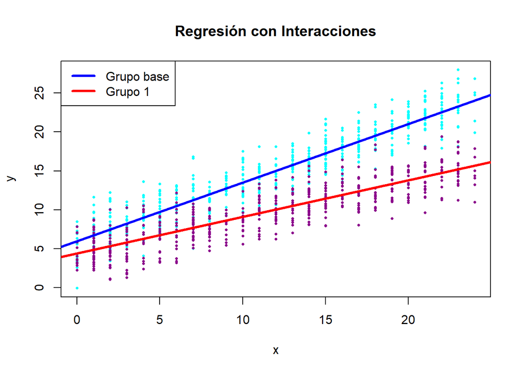

```r
# Replicabilidad
set.seed(700)

# Definicion de parametros poblacionales
b0 <- 6
b1 <- 0.75
d0 <- -2
d1 <- -0.25

# Extraccion de muestra (fuera del grupo)
x <- round(runif(1000, 0, 24))
u <- rnorm(1000, 0, 2)
y_0 <- b0 + b1 * x[1:500] + u[1:500]
y_1 <- (b0 + d0) + (b1 + d1) * x[501:1000] + u[501:1000]

# Estimacion de modelos
mod_0 <- lm(y_0 ~ x[1:500])
mod_1 <- lm(y_1 ~ x[501:1000])

# Graficas
plot(x[1:500], y_0,
     col = "cyan",
     pch = 16, cex = 0.50,
     main = "Regresión con Interacciones",
     xlab = "x",
     ylab = "y")
points(x[501:1000], y_1,
     col = "darkmagenta",
     pch = 16, cex = 0.50,
     add = TRUE)
abline(mod_0, col = "blue", lwd = 3)
abline(mod_1, col = "red", lwd = 3)

# Legend
legend("topleft", lwd = c(3, 3),
       col = c("blue", "red"),
       legen = c("Grupo base", "Grupo 1"))
```

Con la incorporación de un término de interacción al modelo podemos plantear pruebas de hipótesis más interesantes y completas, como por ejemplo si el modelo poblacional es diferente para el grupo base que para el grupo 1. Esto se plantea con la hipótesis
$$\begin{align*}
H_0: &\: \delta_0 = \delta_1 = 0 \\
H_1: &\: H_0 \text{ no es correcta}
\end{align*}$$

## 7.5. Ejemplos

Veamos algunos ejemplos de los conceptos cubiertos.

### 7.5.1. Discriminación Salarial por Razón de Género

Consideremos una pregunta simple: ¿existe discriminación salarial contra las mujeres?

Empecemos considerando el caso más simple: una regresión para explicar el salario usando como únicos regresores la escolaridad y sexo.

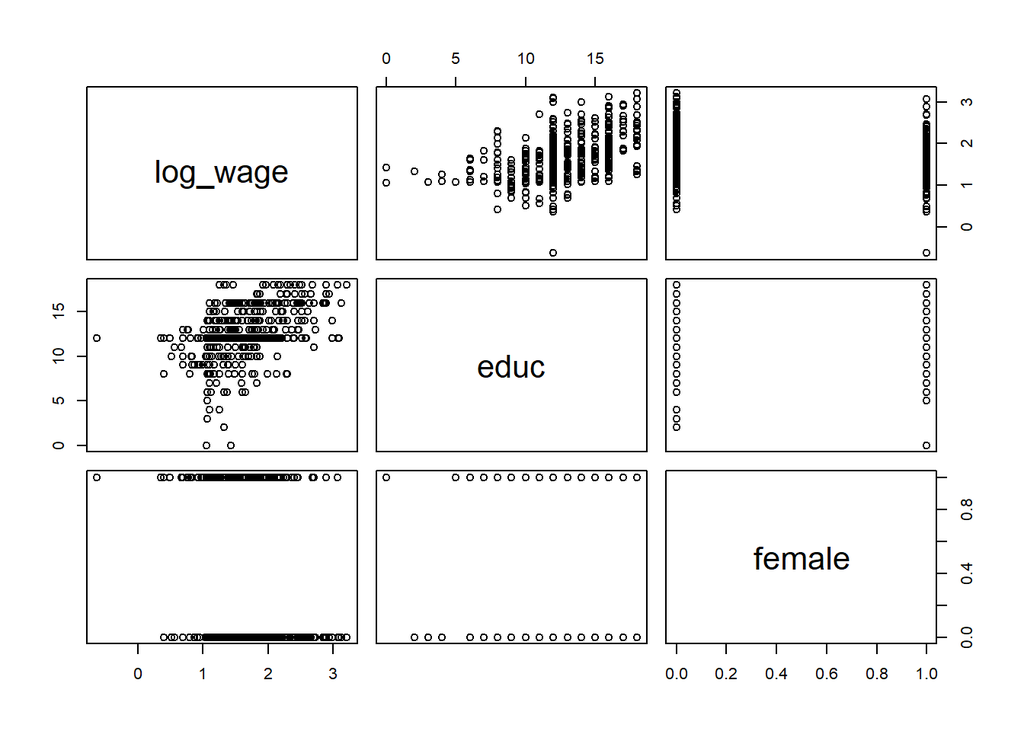

```r
# Carga de datos
data(wage1)

# Seleccion de variables relevantes
base1 <- wage1 %>%
  mutate(log_wage = log(wage)) %>%
  select(log_wage, educ, female)

# Grafica
plot(base1)
```

```r
# Estimacion del modelo
discriminacion_simple <- lm(formula = log_wage ~ educ + female,
                            data = base1)

# Presentacion de resultados
stargazer(discriminacion_simple, digits = 3,
          type = "text", style = "aer",
          dep.var.labels = c("LOG(Salario)"),
          covariate.labels = c("Escolaridad",
                               "Sexo", "Constante"))
```

```
##
## ==========================================================
##                                  LOG(Salario)
## ----------------------------------------------------------
## Escolaridad                        0.077***
##                                    (0.007)
##
## Sexo                              -0.361***
##                                    (0.039)
##
## Constante                          0.826***
##                                    (0.094)
##
## Observations                         526
## R2                                  0.300
## Adjusted R2                         0.298
## Residual Std. Error            0.445 (df = 523)
## F Statistic                112.189*** (df = 2; 523)
## ----------------------------------------------------------
## Notes:              ***Significant at the 1 percent level.
##                     **Significant at the 5 percent level.
##                     *Significant at the 10 percent level.
```

Para descartar la posibilidad de que esta diferencia se deba a “mala suerte” en la muestra aleatoria, proponemos la siguiente prueba de hipótesis (considerando significancia de $\alpha = 0.01$):
$$\begin{align*}
H_0: &\: \beta_2 = 0 \\
H_1: &\: \beta_2 < 0
\end{align*}$$

```r
# Parametros de la prueba
n <- nobs(discriminacion_simple)
k <- 2
alpha <- 0.01

# Calculo del estadistico
beta_female <- summary(discriminacion_simple)$coefficients[3, 1]
se_female <- summary(discriminacion_simple)$coefficients[3, 2]
t_stat <- beta_female / se_female
t_stat
```

```
## [1] -9.247156
```

```r
# Calculo del valor crítico
c <- qt(1 - alpha, n - k - 1)
c
```

```
## [1] 2.333499
```

```r
# Resultado de la prueba
if(t_stat < -c){
  print("Rechazamos H0 a la significancia dada")
}else{
  print("No rechazamos H0")
}
```

```
## [1] "Rechazamos H0 a la significancia dada"
```

```r
# Enfoque del valor-p
# Se calcula el valor p
p_val <- pt(t_stat, n - k - 1)
p_val
```

```
## [1] 2.916493e-19
```

Lo que los resultados indican evidencia muy fuerte en contra de $H_0$.

Gráficamente, lo que el modelo representa es el siguiente fenómeno:

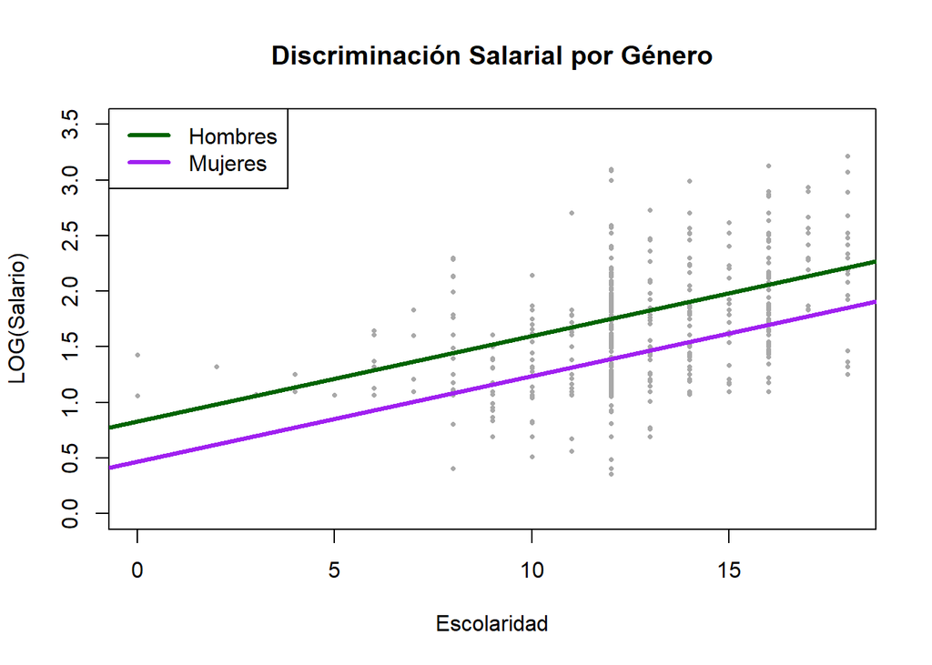

```r
# Grafica puntos
with(base1,
     plot(educ, log_wage,
          col = "dark gray",
          pch = 16, cex = 0.50,
          xlim = c(0, max(educ)),
          ylim = c(0, 3.5),
          main = "Discriminación Salarial por Género",
          xlab = "Escolaridad",
          ylab = "LOG(Salario)"))

# Recta Hombres
abline(a = coef(discriminacion_simple)[[1]],
       b = coef(discriminacion_simple)[[2]],
       col = "darkgreen", lwd = 3)

# Recta Mujeres
abline(a = coef(discriminacion_simple)[[1]] + coef(discriminacion_simple)[[3]],
       b = coef(discriminacion_simple)[[2]],
       col = "purple", lwd = 3)

# Legend
legend("topleft",
       col = c("darkgreen", "purple"),
       lwd = c(3, 3),
       legend = c("Hombres", "Mujeres"))
```

Aunque la evidencia que hemos encontrado indica (muy fuertemente) la existencia de discriminación salarial por motivos de género en contra de las mujeres, esto no basta para establecer una relación causal. Esto es, aunque el modelo presenta resultados contundentes, no nos permite concluir, de manera definitiva, que la diferencia observada entre los salarios de hombres y mujeres se debe, únicamente al género. Para poder establecer esta relación, necesitamos incorporar otros factores de productividad que puedan afectar al salario.

A continuación hacemos un análisis más completo de la discriminación salarial por motivos de género.

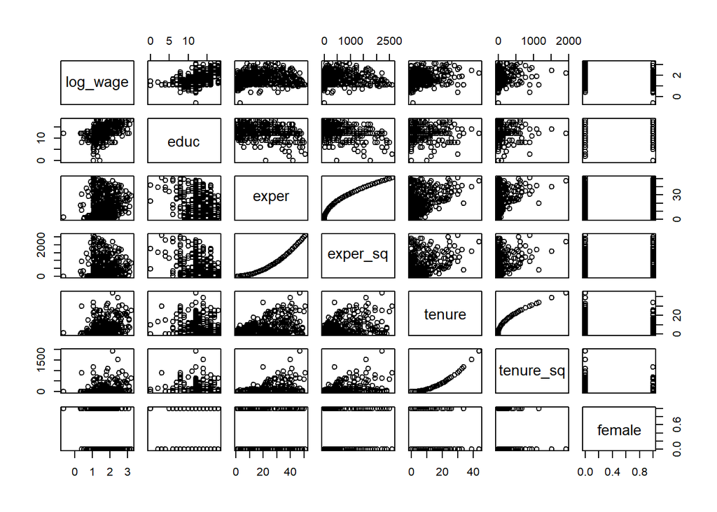

```r
# Carga de datos
data(wage1)

# Seleccion de variables relevantes
base1m <- wage1 %>%
  mutate(log_wage = log(wage),
         exper_sq = exper^2,
         tenure_sq = tenure^2) %>%
  select(log_wage, educ, exper, exper_sq,
         tenure, tenure_sq, female)

# Grafica
plot(base1m)
```

```r
# Estimacion del modelo
discriminacion <- lm(formula = log_wage ~ educ + exper + exper_sq +
                       tenure + tenure_sq + female,
                     data = base1m)

# Presentacion de resultados
stargazer(discriminacion_simple,
          discriminacion,
          digits = 3,
          type = "text", style = "aer",
          dep.var.labels = c("LOG(Salario)"),
          covariate.labels = c("Escolaridad",
                               "Experiencia",
                               "Experiencia SQ",
                               "Antigüedad",
                               "Antigüedad SQ",
                               "Sexo", "Constante"))
```

```
##
## ====================================================================
##                                       LOG(Salario)
##                               (1)                      (2)
## --------------------------------------------------------------------
## Escolaridad                 0.077***                0.080***
##                             (0.007)                  (0.007)
##
## Experiencia                                         0.029***
##                                                      (0.005)
##
## Experiencia SQ                                      -0.001***
##                                                      (0.000)
##
## Antigüedad                                          0.032***
##                                                      (0.007)
##
## Antigüedad SQ                                       -0.001**
##                                                      (0.000)
##
## Sexo                       -0.361***                -0.297***
##                             (0.039)                  (0.036)
##
## Constante                   0.826***                0.417***
##                             (0.094)                  (0.099)
##
## Observations                  526                      526
## R2                           0.300                    0.441
## Adjusted R2                  0.298                    0.434
## Residual Std. Error     0.445 (df = 523)        0.400 (df = 519)
## F Statistic         112.189*** (df = 2; 523) 68.177*** (df = 6; 519)
## --------------------------------------------------------------------
## Notes:              ***Significant at the 1 percent level.
##                     **Significant at the 5 percent level.
##                     *Significant at the 10 percent level.
```

Los resultados indican que las mujeres ganan, en promedio -29.651% que sus contra partes hombres que poseen los mismos niveles de escolaridad, experiencia y antigüedad laboral. Además este efecto es estadísticamente significativo, al menos, al 1%, lo que vuelve a constituir evidencia muy fuerte a favor de la existencia de discriminación salarial en contra de las mujeres.

### 7.5.2. Atractividad y Salarios

Analicemos la relación que existe entre la atractividad de una persona y sus salarios. En particular nos interesa saber si las personas más atractivas perciben salarios mayores que las personas menos atractivas por el simple hecho de ser más atractivas.

Para este análisis se ha construido una variable categórica llamada `looks` la cual divide a la muestra aleatoria en 5 grupos: `looks` $\in \{1, 2, 3, 4, 5 \}$ donde el valor 1 representa a las personas menos atractivas y el 5 a las más atractivas.

Para poder estimar este modelo debemos elegir un “grupo base” que nos sirva como referencia para interpretar los resultados. La elección de este grupo no es relevante salvo para el planteamiento de la ecuación a estimar. Nosotros consideraremos como el grupo base a las personas que son consideradas como menos atractivas (`looks` $=1$):
$$\ln(y)
= \beta_0 + \beta_1 \: educ + \beta_2 exper + \beta_3 \: expersq +
\beta_4 \: looks2 + \beta_5 \: looks3 + \beta_6 \: looks4 + \beta_7 \:
looks5 + u$$

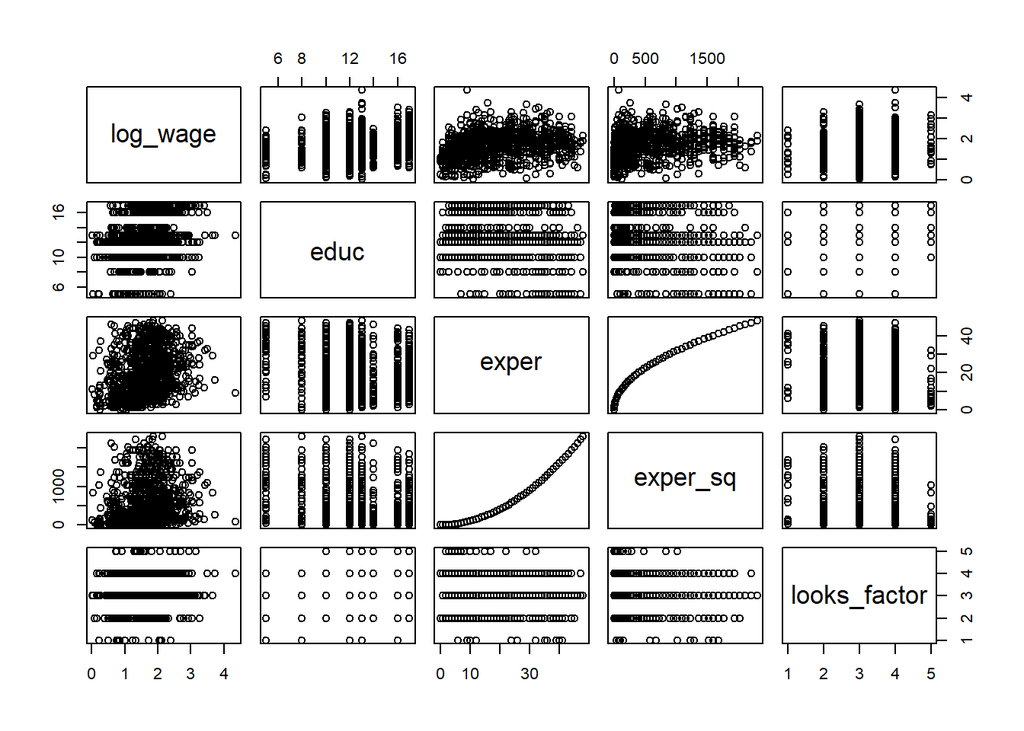

```r
# Carga de datos
data(beauty)

# Seleccion de variables relevantes
base2 <- beauty %>%
  mutate(log_wage = log(wage),
         exper_sq = exper^2,
         looks_factor = as.factor(looks)) %>%
  select(log_wage, educ, exper, exper_sq, looks_factor)

# Grafica
plot(base2)
```

```r
# Estimacion del modelo
atractive1 <- lm(formula = log_wage ~ educ + exper + exper_sq + looks_factor,
                 data = base2)

# Presentacion resultados
stargazer(atractive1, digits = 3,
          type = "text", style = "aer",
          dep.var.labels = c("LOG(Salario)"),
          covariate.labels = c("Escolaridad", "Experiencia",
                               "Experiencia SQ", "Looks 2",
                               "Looks 3", "Looks 4", "Looks 5",
                               "Constante"))
```

```
##
## ==========================================================
##                                  LOG(Salario)
## ----------------------------------------------------------
## Escolaridad                        0.068***
##                                    (0.006)
##
## Experiencia                        0.048***
##                                    (0.005)
##
## Experiencia SQ                    -0.001***
##                                    (0.000)
##
## Looks 2                             0.163
##                                    (0.151)
##
## Looks 3                            0.330**
##                                    (0.146)
##
## Looks 4                            0.310**
##                                    (0.148)
##
## Looks 5                            0.465**
##                                    (0.189)
##
## Constante                           -0.054
##                                    (0.162)
##
## Observations                        1,260
## R2                                  0.238
## Adjusted R2                         0.234
## Residual Std. Error           0.520 (df = 1252)
## F Statistic                56.010*** (df = 7; 1252)
## ----------------------------------------------------------
## Notes:              ***Significant at the 1 percent level.
##                     **Significant at the 5 percent level.
##                     *Significant at the 10 percent level.
```

Los resultados indican que, con respecto a las personas que son consideradas menos atractivas:

- Quienes están clasificadas con `looks` $=2$ ganan 16.29% más.
- Quienes están clasificadas con `looks` $=3$ ganan 32.95% más.
- Quienes están clasificadas con `looks` $=4$ ganan 30.98% más.
- Quienes están clasificadas con `looks` $=5$ ganan 46.54% más.

El mismo modelo, pero considerando a las personas más atractivas (`looks` $=5$) como el grupo de referencia se pudo haber estimado de la siguiente manera:

```r
# Redefinir grupo base
base2$looks_factor <- relevel(base2$looks_factor, "5")

# Estimacion del modelo
atractive5 <- lm(formula = log_wage ~ educ + exper + exper_sq + looks_factor,
                 data = base2)

# Presentacion resultados
stargazer(atractive5, digits = 3,
          type = "text", style = "aer",
          dep.var.labels = c("LOG(Salario)"),
          covariate.labels = c("Escolaridad", "Experiencia",
                               "Experiencia SQ", "Looks 1",
                               "Looks 2", "Looks 3", "Looks 4",
                               "Constante"))
```

```
##
## ==========================================================
##                                  LOG(Salario)
## ----------------------------------------------------------
## Escolaridad                        0.068***
##                                    (0.006)
##
## Experiencia                        0.048***
##                                    (0.005)
##
## Experiencia SQ                    -0.001***
##                                    (0.000)
##
## Looks 1                            -0.465**
##                                    (0.189)
##
## Looks 2                            -0.303**
##                                    (0.128)
##
## Looks 3                             -0.136
##                                    (0.121)
##
## Looks 4                             -0.156
##                                    (0.123)
##
## Constante                          0.411***
##                                    (0.145)
##
## Observations                        1,260
## R2                                  0.238
## Adjusted R2                         0.234
## Residual Std. Error           0.520 (df = 1252)
## F Statistic                56.010*** (df = 7; 1252)
## ----------------------------------------------------------
## Notes:              ***Significant at the 1 percent level.
##                     **Significant at the 5 percent level.
##                     *Significant at the 10 percent level.
```

Los resultados indican que, con respecto a las personas que son consideradas más atractivas:

- Quienes están clasificadas con `looks` $=1$ ganan -46.54%.
- Quienes están clasificadas con `looks` $=2$ ganan -30.25%.
- Quienes están clasificadas con `looks` $=3$ ganan -13.59%.
- Quienes están clasificadas con `looks` $=4$ ganan -15.56%.

Finalmente, un planteamiento más natural podría ser considerar al grupo base a quienes tienen un atractivo “promedio” (`looks` $=3$):

```r
# Redefinir grupo base
base2$looks_factor <- relevel(base2$looks_factor, "3")

# Estimacion del modelo
atractive3 <- lm(formula = log_wage ~ educ + exper + exper_sq + looks_factor,
                 data = base2)

# Presentacion resultados
stargazer(atractive5, atractive1, atractive3,
          digits = 3,
          type = "text", style = "aer",
          column.labels = c("Base Looks=5", "Base Looks=1", "Base Looks=3"),
          dep.var.labels = c("LOG(Salario)"),
          covariate.labels = c("Escolaridad", "Experiencia",
                               "Experiencia SQ", "Looks 1",
                               "Looks 2", "Looks 3",
                               "Looks 4", "Looks 5",
                               "Constante"))
```

```
##
## ========================================================================
##                                               LOG(Salario)
##                                 Base Looks=5  Base Looks=1  Base Looks=3
##                                      (1)           (2)          (3)
## ------------------------------------------------------------------------
## Escolaridad                       0.068***      0.068***      0.068***
##                                    (0.006)       (0.006)      (0.006)
##
## Experiencia                       0.048***      0.048***      0.048***
##                                    (0.005)       (0.005)      (0.005)
##
## Experiencia SQ                    -0.001***     -0.001***    -0.001***
##                                    (0.000)       (0.000)      (0.000)
##
## Looks 1                           -0.465**                    -0.330**
##                                    (0.189)                    (0.146)
##
## Looks 2                           -0.303**        0.163      -0.167***
##                                    (0.128)       (0.151)      (0.048)
##
## Looks 3                            -0.136        0.330**
##                                    (0.121)       (0.146)
##
## Looks 4                            -0.156        0.310**       -0.020
##                                    (0.123)       (0.148)      (0.034)
##
## Looks 5                                          0.465**       0.136
##                                                  (0.189)      (0.121)
##
## Constante                         0.411***       -0.054       0.276***
##                                    (0.145)       (0.162)      (0.085)
##
## Observations                        1,260         1,260        1,260
## R2                                  0.238         0.238        0.238
## Adjusted R2                         0.234         0.234        0.234
## Residual Std. Error (df = 1252)     0.520         0.520        0.520
## F Statistic (df = 7; 1252)        56.010***     56.010***    56.010***
## ------------------------------------------------------------------------
## Notes:                          ***Significant at the 1 percent level.
##                                 **Significant at the 5 percent level.
##                                 *Significant at the 10 percent level.
```

### 7.5.3. Interacciones

Volvemos a estar interesados en explicar el desempeño que un estudiante tendrá en un la universidad a partir de su desempeño en la preparatoria y sus horas de estudio totales. La diferencia es que ahora deseamos sabes si la relación entre estas variables es la misma para hombres que para mujeres.

Como nuestro objetivo es averiguar si existe alguna diferencia entre hombres y mujeres vamos a proponer interacciones entre la variable dummy de género y las demás variables explicativas:
$$cumgpa = \beta_0 + \beta_1 \: female + \beta_2 \:
sat + \beta_3 \: hsperc + \beta_4 \: tothrs + \beta_5 \: female * sat +
\beta_6 \: female * hsperc + \beta_7 \: female * tothrs + u$$
Notemos que este modelo se puede expresar de manera más breve si se factoriza la variable `female`:
$$cumgpa = \beta_0 + \beta_2 \: sat + \beta_3 \:
hsperc + + \beta_4 \: tothrs + female (\beta_1 + \beta_5 \: sat +
\beta_6 hsperc + \beta_7 \: tothrs) + u$$
De esta manera la hipótesis que nos interesa probar (si hay o no diferencia en el modelo dependiendo del género del estudiante) se puede expresar como:
$$\begin{align*}
H_0: &\: \beta_1 = \beta_5 = \beta_6 = \beta_7 = 0 \\
H_1: &\: H_0 \text{ no es correcta}
\end{align*}$$

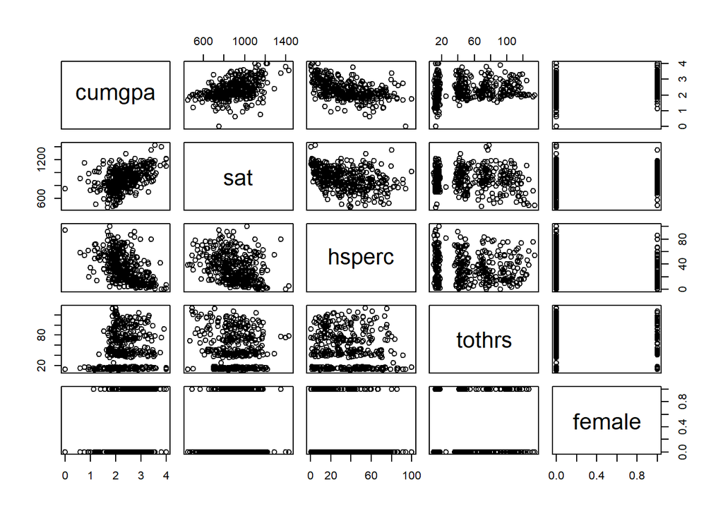

```r
# Carga de datos
data(gpa3)

# Seleccion de variables relevantes
base3 <- gpa3 %>%
  filter(spring == 1) %>%
  select(cumgpa, sat, hsperc, tothrs, female)

# Grafica
plot(base3)
```

```r
# Estimacion del modelo
modelo_diff <- lm(formula = cumgpa ~ female * (sat + hsperc + tothrs),
                  data = base3)

# Presentacion de resultados
stargazer(modelo_diff, digits = 5,
          type = "text", style = "aer",
          dep.var.labels = c("Promedio"),
          covariate.labels = c("Mujer", "SAT", "Percentil Prepa",
                               "Horas Clase", "Mujer * SAT",
                               "Mujer * Percentil Prepa",
                               "Mujer * Horas Clase", "Constante"))
```

```
##
## ==============================================================
##                                        Promedio
## --------------------------------------------------------------
## Mujer                                  -0.35349
##                                       (0.41053)
##
## SAT                                   0.00105***
##                                       (0.00018)
##
## Percentil Prepa                      -0.00845***
##                                       (0.00137)
##
## Horas Clase                           0.00234***
##                                       (0.00086)
##
## Mujer * SAT                            0.00075*
##                                       (0.00039)
##
## Mujer * Percentil Prepa                -0.00055
##                                       (0.00316)
##
## Mujer * Horas Clase                    -0.00012
##                                       (0.00163)
##
## Constante                             1.48081***
##                                       (0.20733)
##
## Observations                             366
## R2                                     0.40593
## Adjusted R2                            0.39431
## Residual Std. Error               0.46783 (df = 358)
## F Statistic                   34.94562*** (df = 7; 358)
## --------------------------------------------------------------
## Notes:                  ***Significant at the 1 percent level.
##                         **Significant at the 5 percent level.
##                         *Significant at the 10 percent level.
```

```r
# Prueba
test <- linearHypothesis(modelo_diff,
                         matchCoefs(modelo_diff, "female"))
test
```

|  | Res.Df | RSS | Df | Sum of Sq | F | Pr(>F) |
| --- | --- | --- | --- | --- | --- | --- |
| 1 | 362 | 85.51507 | NA | NA | NA | NA |
| 2 | 358 | 78.35451 | 4 | 7.160561 | 8.179112 | 2.544637e-06 |

Los resultados de la prueba $F$ indican que, de manera conjunta, la variable `female` es estadísticamente significativa para el modelo, hasta por lo menos el 1%. De hecho usando el valor-$p$ de la prueba tenemos que se puede rechazar $H_0$ con un 99.9997% de confianza.

Esto significa que las rectas estimadas son:

- Para los hombres:
  $$\widehat{cumgpa} =
  1.48081 +
  0.00105 \: sat
  -0.00845 \: hsperc +
  0.00234 \: tothrs$$
- Para las mujeres:
  $$\widehat{cumgpa} =
  1.12733 +
  0.0018 \: sat
  -0.009 \: hsperc +
  0.00223 \: tothrs$$

## 7.6. Ejercicios

1. Considera la base de datos `wage2`.
   Estime el modelo
   $$log(wage) = \beta_0 +
   \beta_1 educ + \beta_2 exper + \beta_3 tenure + \beta_4 married +
   \beta_5 black + u$$
   1. Reporte los resultados en forma de table y de ecuación. Si todos los demás factores se mantienen fijos, ¿cuál es la breca salarial entre los afrodescendientes y los demás grupos? ¿La diferencia es estadísticamente significativa?
   2. Incorpore los términos cuadráticos de `exper` y `tenure` al modelo. Calcule la significancia estadística de estos factores.
   3. Regrese al modelo inicial considerando los grupos afrodescentdientes casados, no-afrodescendientes casados, afrodescendientes solteros y no-afrodescendientes solteros.  
      ¿Cuál es la diferencia salarial estimada para las personas casadas?
2. Considere la base de datos `ceosal1`.
   Estime el modelo
   $$log(salary) = \beta_0 +
   \beta_1 log(sales) + \beta_2 roe + \beta_3 ros + u$$
   1. ¿Qué puede concluir sobre `ros`?
   2. Defina la variable `rosneg` quw toma el valor 1 cuando `ros` $< 0$ y 0 en otro caso.
      Estime el modelo
      $$log(salary) = \beta_0 +
      \beta_1 log(sales) + \beta_2 roe + \beta_3 rosneg + u$$
      Discuta la interpretación y significado económico del coeficiente $\beta_3$.